# Sentiment Analysis of Skincare Product Reviews using NLP

## Overview

This project task is to make a Sentiment Analysis, a common task in natural language processing (NLP), that involves determining the emotional tone of a piece of text, such as a product review. This application can be a useful to apply in e-commerce channels, because it can be used to automatically analyze customer feedback and better tailor responses accordingly.

To complete the task, here it was used two popular algorithms used for sentiment analysis: VADER and BERT. Each one has their own approach and complexity:

- VADER (Valence Aware Dictionary and sEntiment Reasoner) is a rule-based algorithm that relies on a pre-built lexicon of sentiment-laden words to determine the sentiment of a given piece of text. The lexicon contains thousands of words with assigned positive or negative scores based on how they are perceived in context. VADER also uses various rules to handle negations, intensifiers, and emoticons. VADER is often used for quick and simple sentiment analysis tasks, as it's easy to implement and has been shown to perform well in many scenarios.
- BERT (Bidirectional Encoder Representations from Transformers) is a more complex algorithm that uses deep learning to understand the context and meaning of text. It's a neural network-based algorithm that can analyze text at the sentence or document level, and can handle complex language structures like sarcasm, irony, and idioms. BERT is trained on a large corpus of text data and can be fine-tuned for a specific task, such as sentiment analysis. While BERT requires more computational resources and training data compared to VADER, it can provide more accurate results in many scenarios.

Usually, if dealing with short and simple text, like tweets or product reviews, VADER might be a good option. On the other hand, if dealing with longer or more complex text, like news articles or customer feedback surveys, BERT might be a better choice. Even so, this project applied both algorithms to compare their performance on a simple task.

> The dataset used in this project contains data scrapped from Ulta Skincare Reviews, before march 27, 2023. The source is at: [Skincare-Products-Dataset](https://www.kaggle.com/datasets/nenamalikah/nlp-ulta-skincare-reviews)

### 1. Project Set-up

This analysis beggins with the following steps:

- (1) Importing frameworks; (2) Loading data from local repository; (3) Dataset Overview;

```python
import numpy as np
import pandas as pd
import matplotlib.pyplot as plt
%matplotlib inline
import seaborn as sns
```

```python
#Loading data
skin_reviews = pd.read_csv('C:/Users/Samsung/Ulta-Skincare-Reviews.csv')
```

###### 1.1 First look

```python
#Overview
skin_reviews.head()
```

|  | Review_Title | Review_Text | Verified_Buyer | Review_Date | Review_Location | Review_Upvotes | Review_Downvotes | Product | Brand | Scrape_Date |
| --- | --- | --- | --- | --- | --- | --- | --- | --- | --- | --- |
| 0 | Perfect | Love using this on my face while in the shower... | No | 15 days ago | Undisclosed | 0 | 0 | Multi-Vitamin Thermafoliant | Dermalogica | 3/27/23 |
| 1 | You need this | Even better than the daily microfoliant. I'm o... | No | 27 days ago | Undisclosed | 0 | 0 | Multi-Vitamin Thermafoliant | Dermalogica | 3/27/23 |
| 2 | Clean skin | Enjoy this product so much ! I look forward to... | No | 2 months ago | Undisclosed | 0 | 0 | Multi-Vitamin Thermafoliant | Dermalogica | 3/27/23 |
| 3 | Love This Stuff! | I've never tried anything like this before and... | No | 2 months ago | Undisclosed | 0 | 0 | Multi-Vitamin Thermafoliant | Dermalogica | 3/27/23 |
| 4 | This exfoliates very nicely and | This exfoliates very nicely and gives a very s... | No | 2 months ago | Undisclosed | 0 | 0 | Multi-Vitamin Thermafoliant | Dermalogica | 3/27/23 |

##### 1.2. Data types and null values

```python
skin_reviews.info()
```

```
<class 'pandas.core.frame.DataFrame'>
RangeIndex: 4150 entries, 0 to 4149
Data columns (total 10 columns):
 #   Column            Non-Null Count  Dtype
---  ------            --------------  -----
 0   Review_Title      4150 non-null   object
 1   Review_Text       4148 non-null   object
 2   Verified_Buyer    4150 non-null   object
 3   Review_Date       4150 non-null   object
 4   Review_Location   4149 non-null   object
 5   Review_Upvotes    4150 non-null   int64
 6   Review_Downvotes  4150 non-null   int64
 7   Product           4150 non-null   object
 8   Brand             4150 non-null   object
 9   Scrape_Date       4150 non-null   object
dtypes: int64(2), object(8)
memory usage: 324.3+ KB
```

**Note:** Two columns have null values. Because it is only three values (less than 1% of data), we can simply drop them and work with the remaining data

```python
skin_reviews[skin_reviews['Review_Text'].isnull()]
```

|  | Review_Title | Review_Text | Verified_Buyer | Review_Date | Review_Location | Review_Upvotes | Review_Downvotes | Product | Brand | Scrape_Date |
| --- | --- | --- | --- | --- | --- | --- | --- | --- | --- | --- |
| 3684 | Received a sample and loved it! | NaN | Yes | 4 years ago | Columbia, SC | 0 | 0 | Daily Microfoliant | Dermalogica | 3/27/23 |
| 3686 | This product works | NaN | Yes | 4 years ago | Columbia, SC | 0 | 0 | Daily Microfoliant | Dermalogica | 3/27/23 |

```python
skin_reviews.dropna(inplace = True)
```

To better understand the data, let's randomly select a set of Review texts to try to understand what we will see:  
Then, let's look into the titles of reviews, to see if there is a pattern.

```python
print(
    'samples:\n\n', skin_reviews.iloc[0][1],\
    '\n\n', skin_reviews.iloc[17][1], \
    '\n\n', skin_reviews.iloc[151][1], \
    '\n\n', skin_reviews.iloc[633][1], \
    '\n\n', skin_reviews.iloc[1200][1], \
    '\n\n', skin_reviews.iloc[2200][1], \
     '\n\n', skin_reviews.iloc[3040][1],
)
```

```
samples:

 Love using this on my face while in the shower. Heats up and gives a light scrub nicely

 Great product and your skin feels like silk after use.

 Dermalogica's products have always been a hit or miss for me but I'm glad to say that this product is one of the exceptions! Is the few seconds 'warming' sensation when you apply this a bit gimmicky? I used to think so at first, but as I've continued to use it, I'm starting to think this is the one…

 It does it's job but it's not the most spectacular product I've used. It is kind of drying so you definitely have to make sure you moisturize your skin after. It leaves my dry skin a little too dry and tight for my liking.

 I am always Leary of using a cream cleanser I really like the feel of a soap but amazingly enough this works like a charm! My skin felt so clean after using it. I only ordered it this time rather than the daily cleanser because my skin has been so dry this winter but this has certainly helped!

 I like the way this gently exfoliates my skin. The first use, I did pour out too much, but I found that the secret is to turn the container so that the tab over the dispenser hole comes down from the top side, which slows the flow. I've been able to dispense just the right amount each time this way…

 This product was gifted by Dermalogica, but it's the 5th bottle for me! I've purchased this exfoliator again and again because it gently exfoliate ms my skin, without sensitising or stripping my moisture barrier. I think it's the best physical exfoliant I've ever used. I have combination skin and p…
```

```python
# Review Titles
print(
    skin_reviews['Review_Title'].value_counts().sort_values(ascending = False)
)
```

```
Amazing product                                         95
Love this mask                                          90
It's hydrating                                          89
Buy it!                                                 89
Would absolutely buy this again                         89
                                                        ..
Wow I love this!                                         1
Burned my skin                                           1
Warms my skin in a good way                              1
Definitely keeping this in my daily skincare routine     1
Love!!!                                                  1
Name: Review_Title, Length: 2825, dtype: int64
```

## 2. Feature extraction & EDA

```python
#Check if all of scraping column is the same date:
print('Is all scraping from the same day?')
len(skin_reviews['Scrape_Date'].unique()) == 1
```

```
Is all scraping from the same day?
```

```
True
```

```python
#scrubbing review date: which suffix describes the shifts from scrape_date?
skin_reviews['Review_Date'].apply(lambda x: x.split(' ')[1]).unique()
```

```
array(['days', 'months', 'year', 'years', 'month'], dtype=object)
```

```python
from pandas import to_datetime
from dateutil.relativedelta import relativedelta

def extract_data(review_date):
    '''
    This function extracts the date from which the review was made.

    This dataset informs how long the review has been mande since the web scrapping.

    It takes the magnitude of the shift (integer), and the dimension (days, months, years), and returns
    the date of the review
    '''
    #get scrapping date (does not matter, it is all the same)
    ref = pd.to_datetime(max(skin_reviews['Scrape_Date']), format='%m/%d/%y')
    qty, shift = int(review_date.split(' ')[0]), review_date.split(' ')[1]

    if shift in ('days'):
        return ref - pd.Timedelta(days = qty)
    elif shift in ('months', 'month'):
        return ref - relativedelta(months = qty)
    elif shift in ('year', 'years'):
        return ref - relativedelta(years = qty)
    else:
        return ref


skin_reviews['Date_of_Review'] = skin_reviews['Review_Date'].apply(lambda x:extract_data(x))
```

```python
#convert to datetime
skin_reviews['Date_of_Review'] = skin_reviews['Date_of_Review'].apply(lambda x: pd.to_datetime(x, format='%m-%d-%y'))
```

```python
#No need for this column anymore
skin_reviews.drop('Scrape_Date', axis = 1, inplace = True)
```

```python
skin_reviews['text_size'] = skin_reviews['Review_Text'].apply(lambda x: len(x))
skin_reviews['text_size'].sort_values(ascending = False)
```

```
151     1998
2589    1988
2472    1883
205     1780
2536    1746
        ...
1457       5
3560       4
1701       4
457        1
3816       1
Name: text_size, Length: 4147, dtype: int64
```

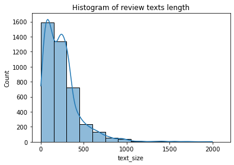

```python
plt.title('Histogram of review texts length')
sns.histplot(data = skin_reviews, x = 'text_size', kde = True, binwidth = 150)
```

###### Brands and Products

- Understanding how they are distributed in the dataset

```python
print('Brands in Dataset: ', skin_reviews['Brand'].nunique())
print('Products in Dataset', skin_reviews['Product'].nunique())
```

```
Brands in Dataset:  1
Products in Dataset 4
```

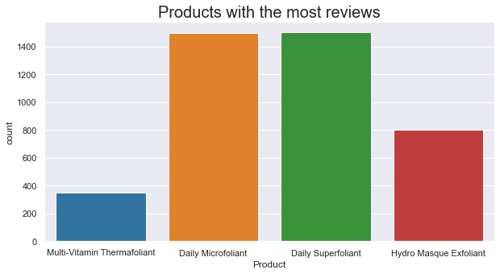

```python
sns.set_context('notebook')
sns.set_style('darkgrid')
plt.figure(figsize=(10,5))
plt.title('Products with the most reviews', fontsize = 20)

sns.countplot(x = skin_reviews['Product'],
              order = ['Multi-Vitamin Thermafoliant',
                       'Daily Microfoliant',
                       'Daily Superfoliant',
                       'Hydro Masque Exfoliant'])
```

```python
verified = pd.DataFrame(skin_reviews['Verified_Buyer'].value_counts())
tmp = verified['Verified_Buyer'].sum()

verified['%'] = verified['Verified_Buyer'].apply(lambda x: f'{x/tmp:.2f}')
verified
```

|  | Verified_Buyer | % |
| --- | --- | --- |
| No | 2900 | 0.70 |
| Yes | 1247 | 0.30 |

```python
skin_reviews['month_review'] = skin_reviews['Date_of_Review'].apply(lambda x: to_datetime(x).month)
skin_reviews['year_review'] = skin_reviews['Date_of_Review'].apply(lambda x: to_datetime(x).year)
skin_reviews['mo-yr'] = (skin_reviews['month_review']).astype(str) + '-' + (skin_reviews['year_review']).astype(str)
```

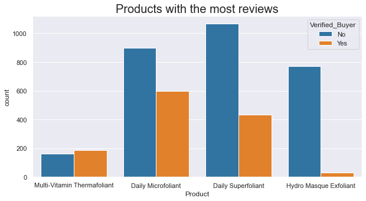

```python
sns.set_context('notebook')
sns.set_style('darkgrid')
plt.figure(figsize=(10,5))
plt.title('Products with the most reviews', fontsize = 20)
sns.countplot(x = skin_reviews['Product'], hue = skin_reviews['Verified_Buyer'], palette = 'tab10',
              #x = skin_reviews[skin_reviews['Verified_Buyer'] == 'Yes']['Product'],
              order = ['Multi-Vitamin Thermafoliant',
                       'Daily Microfoliant',
                       'Daily Superfoliant',
                       'Hydro Masque Exfoliant'])
```

```python
#skin_reviews.sort_values('Date_of_Review', inplace = True)
df = pd.DataFrame(skin_reviews.groupby('mo-yr')['Review_Title'].count().reset_index())
df = df.merge(skin_reviews[['mo-yr', 'month_review', 'year_review']].drop_duplicates(), on ='mo-yr')

visual_df = df.sort_values(['year_review', 'month_review'], ascending = True).set_index('mo-yr').drop(['month_review', 'year_review'], axis = 1)
```

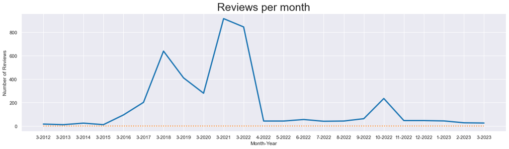

```python
sns.set_context('notebook')
plt.figure(figsize=(20,5))
plt.title('Reviews per month', fontsize = 25)
sns.lineplot(x = visual_df.index, y = visual_df.Review_Title, lw = 3 )
sns.lineplot(x = visual_df.index, y = 0, lw =2, ls = 'dotted')
plt.xlabel('Month-Year')
plt.ylabel('Number of Reviews')
```

Because the date of review was extracted from the time past scrapping, it does not tell the specific day of review. Therefore, only dates within one year can be relied on for time series analysis:

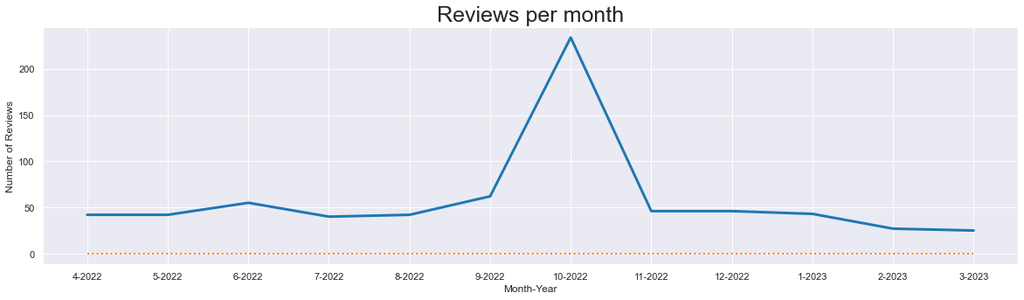

```python
sns.set_context('notebook')
plt.figure(figsize=(20,5))
plt.title('Reviews per month', fontsize = 25)
sns.lineplot(x = visual_df.loc['4-2022':].index, y = visual_df.loc['4-2022':].Review_Title, lw = 3 )
sns.lineplot(x = visual_df.loc['4-2022':].index, y = 0, lw =2, ls = 'dotted')
plt.xlabel('Month-Year')
plt.ylabel('Number of Reviews')
```

The above charts points a peak in sales during october, which may be due to events and promotions, or something deeper, which will be investigated

## 3. VADER Model

#### - Setting up texts using NLTK

Next steps:

- Use NLTK `SentimentIntensityAnalyzer` to identify through BoW (Bag of Words) if a text indicates a positive, neutral ou negative review. It is a good method, although it might make mistakes because it does not consider context within a text;
- Analyze data with resulting values;
- Use roBERTa pre-trained model to predict customers sentiment, using a more complex approach;

```python
from nltk.sentiment import SentimentIntensityAnalyzer
from nltk import downloader
#downloader.download('vader_lexicon')

sia = SentimentIntensityAnalyzer()

results = {}

for i, row in skin_reviews.iterrows():
    text = row['Review_Text']
    results[i] = sia.polarity_scores(text)
```

```python
results = pd.DataFrame(results).T
results
```

|  | neg | neu | pos | compound |
| --- | --- | --- | --- | --- |
| 0 | 0.000 | 0.679 | 0.321 | 0.7964 |
| 1 | 0.102 | 0.723 | 0.175 | 0.2960 |
| 2 | 0.000 | 0.583 | 0.417 | 0.8347 |
| 3 | 0.031 | 0.749 | 0.220 | 0.8636 |
| 4 | 0.227 | 0.618 | 0.156 | -0.3430 |
| ... | ... | ... | ... | ... |
| 4145 | 0.000 | 0.580 | 0.420 | 0.4404 |
| 4146 | 0.066 | 0.825 | 0.110 | 0.7163 |
| 4147 | 0.000 | 0.734 | 0.266 | 0.4404 |
| 4148 | 0.115 | 0.783 | 0.102 | 0.0518 |
| 4149 | 0.000 | 0.799 | 0.201 | 0.8209 |

4147 rows × 4 columns

```python
vader_df = results.reset_index().join(skin_reviews[['Review_Title', 'Review_Text', 'Verified_Buyer', 'Product', 'mo-yr']]).\
           drop(labels = 'index', axis = 1)
vader_df
```

|  | neg | neu | pos | compound | Review_Title | Review_Text | Verified_Buyer | Product | mo-yr |
| --- | --- | --- | --- | --- | --- | --- | --- | --- | --- |
| 0 | 0.000 | 0.679 | 0.321 | 0.7964 | Perfect | Love using this on my face while in the shower... | No | Multi-Vitamin Thermafoliant | 3-2023 |
| 1 | 0.102 | 0.723 | 0.175 | 0.2960 | You need this | Even better than the daily microfoliant. I'm o... | No | Multi-Vitamin Thermafoliant | 2-2023 |
| 2 | 0.000 | 0.583 | 0.417 | 0.8347 | Clean skin | Enjoy this product so much ! I look forward to... | No | Multi-Vitamin Thermafoliant | 1-2023 |
| 3 | 0.031 | 0.749 | 0.220 | 0.8636 | Love This Stuff! | I've never tried anything like this before and... | No | Multi-Vitamin Thermafoliant | 1-2023 |
| 4 | 0.227 | 0.618 | 0.156 | -0.3430 | This exfoliates very nicely and | This exfoliates very nicely and gives a very s... | No | Multi-Vitamin Thermafoliant | 1-2023 |
| ... | ... | ... | ... | ... | ... | ... | ... | ... | ... |
| 4142 | 0.000 | 0.580 | 0.420 | 0.4404 | Love this product!! | Love, love, love the feel of my skin after I u... | Yes | Daily Microfoliant | 3-2016 |
| 4143 | 0.066 | 0.825 | 0.110 | 0.7163 | Great daily exfoliator. | After trying a sample of this product I decide... | Yes | Daily Microfoliant | 3-2016 |
| 4144 | 0.000 | 0.734 | 0.266 | 0.4404 | Facials to go | Simple pouring none abrasive | Yes | Daily Microfoliant | 3-2016 |
| 4145 | 0.115 | 0.783 | 0.102 | 0.0518 | I would buy this product again | Much better product than a scrub. | Yes | Daily Microfoliant | 3-2016 |
| 4146 | 0.000 | 0.799 | 0.201 | 0.8209 | Gentle exfoliant- leaves skin smooth & soft | I've been using this exfoliant for a few month... | No | Daily Microfoliant | 3-2016 |

4147 rows × 9 columns

#### Taking a Deeper look Negative Reviews:

**For a quick overview, let's define a threshold of being a negative review of 35% or over, and look at the texts:**

*Obs: Let's also look the probability of being a positive review, to ensure the model really knows what it is classifying*

```python
vader_df.loc[(vader_df['neg'] > 0.35),['neg','pos', 'Review_Text']]
```

|  | neg | pos | Review_Text |
| --- | --- | --- | --- |
| 409 | 0.500 | 0.000 | This is non irritating |
| 500 | 0.401 | 0.064 | I would not recommend this product for people ... |
| 1717 | 0.462 | 0.000 | Keeps the dead skin cells away |
| 1929 | 0.595 | 0.000 | Smells horrific. Won't repurchase. |
| 2372 | 0.394 | 0.000 | I'm not impressed by it at all. It's messy and... |
| 3466 | 0.395 | 0.275 | I really wish this worked for me because I lov... |

The texts are too long, so it needs to be read in other way:

```python
print(
    ' 1 ', vader_df.loc[409,'Review_Text'], '\n',
    '2 ', vader_df.loc[500,'Review_Text'], '\n',
    '3 ', vader_df.loc[1717,'Review_Text'], '\n',
    '4 ', vader_df.loc[1929,'Review_Text'],'\n',
    '5 ', vader_df.loc[2372,'Review_Text'],'\n',
    '6 ', vader_df.loc[3466,'Review_Text'], '\n'
)
```

```
 1  This is non irritating
 2  I would not recommend this product for people with sensitive skin . It broke my face and neck out terribly. It was a rash like breakout and burned so bad .
 3  Keeps the dead skin cells away
 4  Smells horrific. Won't repurchase.
 5  I'm not impressed by it at all. It's messy and I don't like the application.
 6  I really wish this worked for me because I love the precleanse and special cleansing gel. This broke me out so bad and caused my skin to have this weird uneven texture, though. I stopped using it a few days ago and went back to my very simple routine I have had for the past 15yrs. I'm already gl…
```

##### Taking a deeper look Positive Reviews :

```python
vader_df.loc[(vader_df['pos'] > 0.35),['neg','pos', 'Review_Text']]
```

|  | neg | pos | Review_Text |
| --- | --- | --- | --- |
| 2 | 0.0 | 0.417 | Enjoy this product so much ! I look forward to... |
| 6 | 0.0 | 0.818 | Absolutely love |
| 8 | 0.0 | 0.558 | Definitely love it! My skin face feels better ... |
| 10 | 0.0 | 0.412 | Love this product to exfoliate the skin. |
| 13 | 0.0 | 0.712 | Great product. Always feel gently exfoliated. ... |
| ... | ... | ... | ... |
| 4112 | 0.0 | 0.375 | I use this product before bed and leaves my sk... |
| 4115 | 0.0 | 0.353 | I love how my face feels after using this. |
| 4117 | 0.0 | 0.506 | The is one product worth the money and I alway... |
| 4139 | 0.0 | 0.594 | I noticed a difference almost immediately! I h... |
| 4142 | 0.0 | 0.420 | Love, love, love the feel of my skin after I u... |

888 rows × 3 columns

[output not shown]

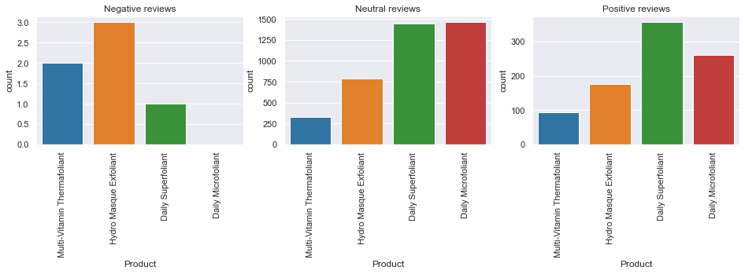

```python
fig, ax = plt.subplots(1, 3, sharex = True, figsize=(16,3))


sns.countplot(data = vader_df, x = vader_df['Product'].loc[(vader_df['neg'] > 0.35)], ax = ax[0], )
ax[0].set_title('Negative reviews')
ax[0].set_xticklabels(ax[0].get_xticklabels(), rotation=90)

sns.countplot(data = vader_df,
              x = vader_df['Product'].loc[(vader_df['neu'] > 0.35)], ax = ax[1])
ax[1].set_title('Neutral reviews')
ax[1].set_xticklabels(ax[1].get_xticklabels(), rotation=90)


sns.countplot(data = vader_df,
              x = vader_df['Product'].loc[(vader_df['pos'] > 0.35)], ax = ax[2])
ax[2].set_title('Positive reviews')
ax[2].set_xticklabels(ax[2].get_xticklabels(), rotation=90)
```

The previous chart used a threshold probability to define the sentiment of a product's review. To get a better estimate, the next plotting will consider the predominant sentiment detected by the algorithm, to classify it as negative, neutral or Positive:

[output not shown]

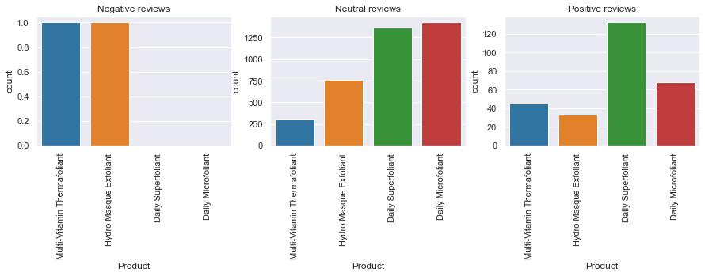

```python
#Reviews Predominently negative, neutral or positive

fig, ax = plt.subplots(1, 3, sharex = True, figsize=(15,3))



sns.countplot(data = vader_df,
              x = vader_df['Product'].loc[(vader_df['neg'] > vader_df['pos']) & (vader_df['neg'] > vader_df['neu'])],
              ax = ax[0],
              palette = 'tab10'
             )
ax[0].set_title('Negative reviews')
ax[0].set_xticklabels(ax[0].get_xticklabels(), rotation=90)



sns.countplot(data = vader_df,
              x = vader_df['Product'].loc[(vader_df['neu'] > vader_df['neg']) & (vader_df['neu'] > vader_df['pos'])],
              ax = ax[1],
              palette = 'tab10'
             )
ax[1].set_title('Neutral reviews')
ax[1].set_xticklabels(ax[1].get_xticklabels(), rotation=90)




sns.countplot(data = vader_df,
              x = vader_df['Product'].loc[(vader_df['pos'] > vader_df['neg']) & (vader_df['pos'] > vader_df['neu'])],
              ax = ax[2],
              palette = 'tab10'
             )
ax[2].set_title('Positive reviews')
ax[2].set_xticklabels(ax[2].get_xticklabels(), rotation=90)
```

Now, it will be created a new field at the dataframe with the predicted class of review, and see it behaving month by month:

```python
def classify(df):
    if (df['neg'] >= df['neu']) & (df['neg'] >= df['pos']):
        return 'negative'
    elif(df['pos'] >= df['neg']) & (df['pos'] >= df['neu']):
        return 'positive'
    else:
        return 'neutral'



vader_df['class'] = vader_df.apply(lambda x: classify(x), axis = 1)
```

```python
vader_df = vader_df.merge(pd.get_dummies(vader_df['class']), how = 'left', on = vader_df.index)
vader_df.drop('key_0',axis = 1, inplace = True)
```

```python
group_df = pd.DataFrame(vader_df.groupby('mo-yr', axis = 0)[['negative', 'positive', 'neutral']].sum())
group_df_order = visual_df.reset_index().merge(group_df, on = 'mo-yr').set_index('mo-yr')
```

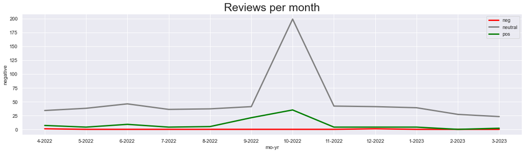

```python
plt.figure(figsize=(20,5))
plt.title('Reviews per month', fontsize = 25)
sns.lineplot(x = group_df_order.loc['4-2022':].index, y = group_df_order.loc['4-2022':]['negative'], lw = 3, label = 'neg', color = 'red' )
sns.lineplot(x = group_df_order.loc['4-2022':].index, y = group_df_order.loc['4-2022':]['neutral'], lw = 3, label = 'neutral', color = 'gray' )
sns.lineplot(x = group_df_order.loc['4-2022':].index, y = group_df_order.loc['4-2022':]['positive'], lw = 3 , label = 'pos', color = 'green')
plt.legend()
```

**It can be seen that in september it had an increase in positive reviews versus overall reviews, whereas in october, even though it grew in number, the overall reviews had a sharp increase in neutral sentiment, which may caused the number of sales to reduce (in other words, normalize) in the next months.**

# 3. BERT model

- **Importing transformers & pytorch frameworks**

According to Hugging Face community, the creators of the "transformers" library, it is a State-of-the-art Machine Learning for PyTorch, TensorFlow, and JAX. In a nutshell:

> 🤗 Transformers provides APIs and tools to easily download and train state-of-the-art pretrained models. Using pretrained models can reduce your compute costs, carbon footprint, and save you the time and resources required to train a model from scratch. These models support common tasks in different modalities, such as:

> (1) 📝 Natural Language Processing: text classification, named entity recognition, question answering, **Sentiment Analysis**, language modeling, summarization, translation, multiple choice, and text generation. (2) 🖼️ Computer Vision: image classification, object detection, and segmentation. (3) 🗣️ Audio: automatic speech recognition and audio classification. (4) 🐙 Multimodal: table question answering, optical character recognition, information extraction from scanned documents, video classification, and visual question answering.

For this project, it will be used a **pretrained model over ~58M tweets and finetuned for sentiment analysis with the TweetEval benchmark**. The source can be found at [Hugging-Face-index](https://huggingface.co/docs/transformers/index)

```python
from transformers import AutoTokenizer
from transformers import AutoModelForSequenceClassification
import torch

BERTtokens = AutoTokenizer.from_pretrained("cardiffnlp/twitter-roberta-base-sentiment")
```

```python
model = AutoModelForSequenceClassification.from_pretrained("cardiffnlp/twitter-roberta-base-sentiment")
```

After downloading the model, we can use it to calculate the predicted sentiments, and apply a `softmax` function to return the probabilities for each state.

```python
from scipy.special import softmax

def polar_scores(row):
    encoded = BERTtokens(row, return_tensors = 'pt')
    result = model(**encoded)
    scores = result[0][0].detach().numpy()
    scores = softmax(scores)
    weights = {
        'negative':scores[0],
        'neutral':scores[1],
        'positive':scores[2]
    }
    return weights
```

```python
BERT_result = {}

for i, row in skin_reviews.iterrows():
    try:
        text = row['Review_Text']
        BERT_result[i] = polar_scores(text)
    except RunTimeError:
        print('error in row:  ', i)
```

```python
BERT_result = pd.DataFrame(BERT_result).T
BERT_result
```

|  | negative | neutral | positive |
| --- | --- | --- | --- |
| 0 | 0.001830 | 0.026186 | 0.971984 |
| 1 | 0.002205 | 0.010915 | 0.986879 |
| 2 | 0.001785 | 0.004618 | 0.993598 |
| 3 | 0.003368 | 0.013725 | 0.982907 |
| 4 | 0.001623 | 0.013866 | 0.984511 |
| ... | ... | ... | ... |
| 4145 | 0.176956 | 0.406029 | 0.417014 |
| 4146 | 0.085561 | 0.312467 | 0.601972 |
| 4147 | 0.003988 | 0.046380 | 0.949632 |
| 4148 | 0.873459 | 0.112970 | 0.013571 |
| 4149 | 0.001571 | 0.011577 | 0.986853 |

4147 rows × 3 columns

Lastly, both vader and BERT results will be combined at a dataframe, and plotted against each other to see if they differ much. Also, let's suppose that 'upvotes' highlights comments that reflects how the community sees the product

```python
df_combined = BERT_result.join(results, rsuffix= 'vader', lsuffix = 'BERT')
df_combined.columns = ['BERT_neg', 'BERT_neutral', 'BERT_pos', 'vader_neg', 'vader_neutral', 'vader_pos', 'vader_comp']
```

```python
df_combined
```

|  | BERT_neg | BERT_neutral | BERT_pos | vader_neg | vader_neutral | vader_pos | vader_comp |
| --- | --- | --- | --- | --- | --- | --- | --- |
| 0 | 0.001830 | 0.026186 | 0.971984 | 0.000 | 0.679 | 0.321 | 0.7964 |
| 1 | 0.002205 | 0.010915 | 0.986879 | 0.102 | 0.723 | 0.175 | 0.2960 |
| 2 | 0.001785 | 0.004618 | 0.993598 | 0.000 | 0.583 | 0.417 | 0.8347 |
| 3 | 0.003368 | 0.013725 | 0.982907 | 0.031 | 0.749 | 0.220 | 0.8636 |
| 4 | 0.001623 | 0.013866 | 0.984511 | 0.227 | 0.618 | 0.156 | -0.3430 |
| ... | ... | ... | ... | ... | ... | ... | ... |
| 4145 | 0.176956 | 0.406029 | 0.417014 | 0.000 | 0.580 | 0.420 | 0.4404 |
| 4146 | 0.085561 | 0.312467 | 0.601972 | 0.066 | 0.825 | 0.110 | 0.7163 |
| 4147 | 0.003988 | 0.046380 | 0.949632 | 0.000 | 0.734 | 0.266 | 0.4404 |
| 4148 | 0.873459 | 0.112970 | 0.013571 | 0.115 | 0.783 | 0.102 | 0.0518 |
| 4149 | 0.001571 | 0.011577 | 0.986853 | 0.000 | 0.799 | 0.201 | 0.8209 |

4147 rows × 7 columns

```python
def votes(upvotes):
    if upvotes > 1:
        return 'upvoted'
    else:
        return 'no-votes'


df_combined['upvotes'] = skin_reviews['Review_Upvotes'].apply(lambda x: votes(x))
df_combined
```

|  | BERT_neg | BERT_neutral | BERT_pos | vader_neg | vader_neutral | vader_pos | vader_comp | upvotes |
| --- | --- | --- | --- | --- | --- | --- | --- | --- |
| 0 | 0.001830 | 0.026186 | 0.971984 | 0.000 | 0.679 | 0.321 | 0.7964 | no-votes |
| 1 | 0.002205 | 0.010915 | 0.986879 | 0.102 | 0.723 | 0.175 | 0.2960 | no-votes |
| 2 | 0.001785 | 0.004618 | 0.993598 | 0.000 | 0.583 | 0.417 | 0.8347 | no-votes |
| 3 | 0.003368 | 0.013725 | 0.982907 | 0.031 | 0.749 | 0.220 | 0.8636 | no-votes |
| 4 | 0.001623 | 0.013866 | 0.984511 | 0.227 | 0.618 | 0.156 | -0.3430 | no-votes |
| ... | ... | ... | ... | ... | ... | ... | ... | ... |
| 4145 | 0.176956 | 0.406029 | 0.417014 | 0.000 | 0.580 | 0.420 | 0.4404 | no-votes |
| 4146 | 0.085561 | 0.312467 | 0.601972 | 0.066 | 0.825 | 0.110 | 0.7163 | no-votes |
| 4147 | 0.003988 | 0.046380 | 0.949632 | 0.000 | 0.734 | 0.266 | 0.4404 | upvoted |
| 4148 | 0.873459 | 0.112970 | 0.013571 | 0.115 | 0.783 | 0.102 | 0.0518 | no-votes |
| 4149 | 0.001571 | 0.011577 | 0.986853 | 0.000 | 0.799 | 0.201 | 0.8209 | no-votes |

4147 rows × 8 columns

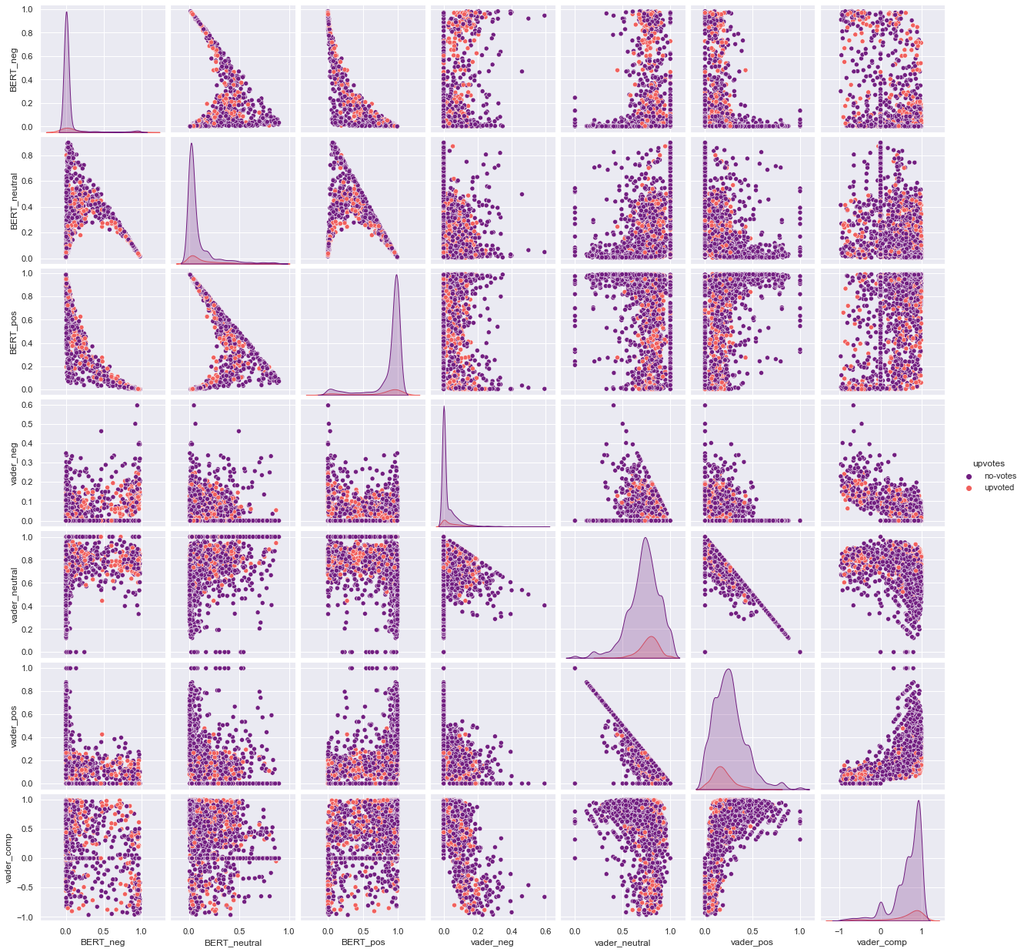

```python
sns.pairplot(data = df_combined, hue = 'upvotes', palette = 'magma')
```

# 4. Conclusion

Even though both models are doing the same task, it should be seen a positve correlation between both models predictions of negative, neutral and positive probabilities to the same row. However, it is not what is seen, because the data is completely scattered. As a result, it can be understood that the vader and BERT models have many different interpretations on the data.  
As it was could be seen, the vader model does not interpret semmantics, and text containg words like "non" or "dead" are bound to be negative statements, which is reality was not true. Therefore, the BERT model corrects those mistakes and results in a much more reliable model for this sentiment analysis